# ex1

```python
!pip show astropy
```

```
Name: astropy
Version: 7.0.1
Summary: Astronomy and astrophysics core library
Home-page:
Author:
Author-email: The Astropy Developers <astropy.team@gmail.com>
License: BSD-3-Clause
Location: C:\Users\btcya\Desktop\astronomy-course-programming\astrocourse\Lib\site-packages
Requires: astropy-iers-data, numpy, packaging, pyerfa, PyYAML
Required-by:
```

```python
# Import the package
import astropy

# Check the installed version
print(astropy.__version__)
```

```
7.0.1
```

### Explanation of the Code

1. **Import Required Libraries**:
   - `numpy`: For numerical operations.
   - `matplotlib.pyplot`: For plotting data.
   - `astropy.io.fits`: For reading FITS (Flexible Image Transport System) files.
   - `astropy.wcs`: For handling World Coordinate System (WCS) information.
   - `astropy.table`: For working with tabular data.
   - `astropy.visualization.make_lupton_rgb`: For creating RGB images (not used in this code).
   - `plt.ion()`: Enables interactive mode for Matplotlib, allowing plots to update dynamically.
2. **Open and Read FITS File**:
   - The FITS file `hst_results_nd.fits` is opened using `fits.open`.
   - The header (`hdr`) is extracted from the first HDU (Header Data Unit) to access metadata.
   - A WCS object (`wcs`) is created from the header for celestial coordinate transformations.
   - The data (`data`) is extracted from the first HDU.
3. **Read the Table from FITS File**:
   - The FITS file is read as an Astropy table (`t`), which contains tabular data such as star positions and magnitudes.
4. **Access and Print Table Information**:
   - The Right Ascension (RA) and Declination (DEC) of the first row in the table are extracted.
   - The column names of the table are retrieved and printed.
5. **Plot All Stars in the Table**:
   - A scatter plot is created using the RA and DEC values of all stars in the table.
   - The x-axis is labeled as "RA", and the y-axis is labeled as "DEC".
   - The plot is titled "All stars in the table".

[figure not shown]

6. **Plot Stars with Smaller Red Markers**:
   - Another scatter plot is created with red circular markers (`'ro'`) and a smaller marker size (`markersize=1`) for better distinction.
   - The x-axis is labeled as "RA", and the y-axis is labeled as "DEC".
   - The plot is titled "All stars in the table".

[figure not shown]

### Summary:

- The code reads a FITS file containing astronomical data.
- It extracts the RA and DEC of stars from the table and plots them in two ways:
  1. A default scatter plot.
  2. A scatter plot with smaller red markers for better distinction.
- The WCS object (`wcs`) is initialized but not used in this code. It could be used for coordinate transformations if needed.

```
['Name', 'RA', 'DEC', 'HST_WFC3_F225W', 'HST_WFC3_F275W', 'HST_WFC3_F336W', 'HST_WFC3_F475W', 'HST_WFC3_F814W', 'HST_WFC3_F110W', 'HST_WFC3_F160W', 'Av_Best', 'Av_Exp', 'Av_p16', 'Av_p50', 'Av_p84', 'Rv_Best', 'Rv_Exp', 'Rv_p16', 'Rv_p50', 'Rv_p84', 'Rv_A_Best', 'Rv_A_Exp', 'Rv_A_p16', 'Rv_A_p50', '…
```

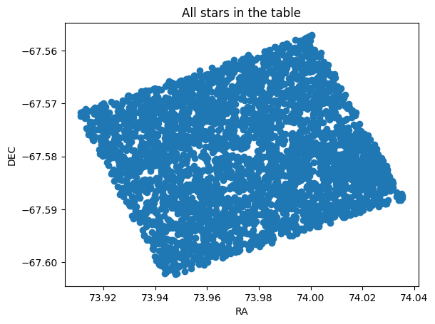

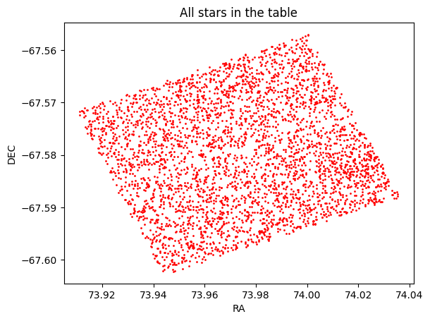

```python
import numpy as np
import matplotlib.pyplot as plt
from astropy.io import fits
from astropy.wcs import WCS
from astropy.table import Table
from astropy.visualization import make_lupton_rgb
plt.ion()

hdul = fits.open('hst_results_nd.fits')


hdr = hdul[0].header
wcs = WCS(hdr)
data = hdul[0].data

t = Table.read('hst_results_nd.fits')

# check all stars in the table which are the first row of the table
ra = t[0]['RA']
dec = t[0]['DEC']
columns = t[0].colnames
print(columns)

# plot the table of all stars
plt.figure()
plt.plot(t['RA'], t['DEC'], 'o')
plt.xlabel('RA')
plt.ylabel('DEC')
plt.title('All stars in the table')
plt.savefig('all_stars.png')
plt.show()


# plot the start with smaller red spots so that they can be distinguished
plt.figure()
plt.plot(t['RA'], t['DEC'], 'ro', ls= 'None', markersize = 1)
plt.xlabel('RA')
plt.ylabel('DEC')
plt.title('All stars in the table')
plt.savefig('all_stars_distinguished.png')
plt.show()
```

### Summary:

This code creates a scatter plot of stars with their positions (`RA`, `DEC`) and colors mapped to the `Av_p50` extinction values. The plot is saved as a file`lmc_av_spacial.png` and includes a color bar for reference.

- The scatter plot shows the spatial distribution of stars in the table, with their colors representing the `Av_p50` values.
- The color bar provides a reference for interpreting the color scale, with values ranging from 0 to 1.
- This visualization is useful for studying the spatial variation of extinction (`Av_p50`) across the stars in the dataset. It helps identify regions with higher or lower extinction values.

[figure not shown]

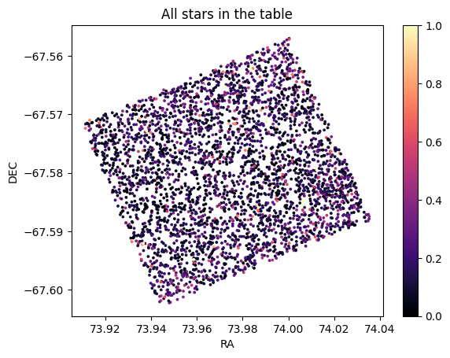

```python
# use 'Av_p50' to plot the color of the stars
plt.figure()
plt.scatter(t['RA'], t['DEC'], s=3, c = t['Av_p50'], cmap = 'magma', vmin=0, vmax=1)
plt.xlabel('RA')
plt.ylabel('DEC')
plt.title('All stars in the table')
plt.colorbar()
plt.savefig('lmc_av_spacial.png')
plt.show()
```

1. **Purpose**:
   - This code creates a histogram to visualize the distribution of distances (`distance_p50`) of stars in the dataset.
   - It calculates and displays the mean and median distances on the plot for reference.
2. **Statistical Calculations**:
   - `d_mean = np.mean(dist)`: Calculates the mean distance.
   - `d_median = np.median(dist)`: Calculates the median distance.
   - `d_std = np.std(dist)`: Calculates the standard deviation of the distances (not directly used in the plot).

### Output:

- A histogram showing the distribution of distances (in kiloparsecs) of stars.
- Red dashed line: Indicates the mean distance.
- Gray dashed line: Indicates the median distance.
- Text annotations: Display the mean and median values on the plot.

[figure not shown]

### Use Case:

This visualization helps analyze the distribution of distances of stars in the dataset, providing insights into the spread and central tendency (mean and median) of the distances.

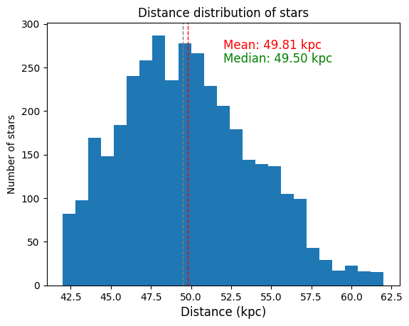

```python
dist=t['distance_p50']
plt.figure()
plt.hist(dist/1000, bins=25)
plt.xlabel('Distance (kpc)', fontsize=12)
plt.ylabel('Number of stars')
plt.title('Distance distribution of stars')
d_mean = np.mean(dist)
d_median = np.median(dist)
d_std = np.std(dist)
plt.axvline(d_mean/1000, color='r', linestyle='dashed', linewidth=1)
plt.axvline(d_median/1000, color='gray', linestyle='dashed', linewidth=1)
plt.text(0.5, 0.9, 'Mean: {:.2f} kpc'.format(d_mean/1000), color='r', fontsize=12, transform=plt.gca().transAxes)
plt.text(0.5, 0.85, 'Median: {:.2f} kpc'.format(d_median/1000), color='g', fontsize=12, transform=plt.gca().transAxes)
plt.savefig('lmc_hist_dist.png')
plt.show()
```

### Output:

- A **color-magnitude diagram** (CMD) is generated, showing the relationship between the color index (`f475w - f814w`) and the magnitude (`f475w`) for stars in the dataset.
- The x-axis represents the color index, while the y-axis represents the magnitude (inverted for brighter stars).
- The plot is saved as `lmc_color_f475.png`.

[figure not shown]

### Use Case:

This CMD is useful for studying the stellar population of the dataset, identifying different types of stars, and analyzing their properties based on their color and brightness.

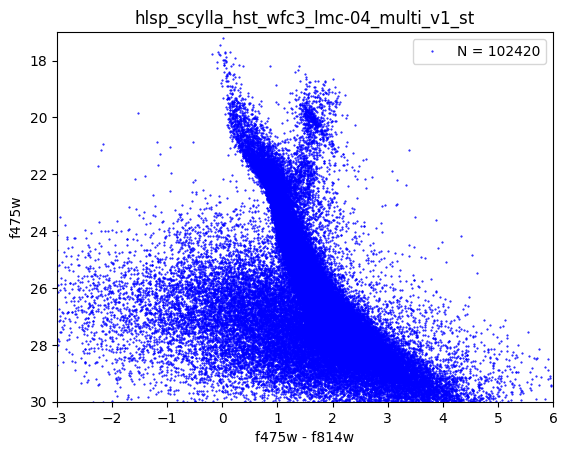

```python
# Read the FITS file into an Astropy table
cat = Table.read('hlsp_scylla_hst_wfc3_lmc-04_multi_v1_st.fits')

# Extract the F475W and F814W magnitudes in the Vega system
f475 = cat["F475W_VEGA"]
f814 = cat["F814W_VEGA"]

# Calculate the number of stars in the dataset
n = len(f475)

# Compute the color (f475w - f814w) and magnitude (f475w)
col = f475 - f814
mag = f475

# Create a color-magnitude diagram
plt.figure()
plt.plot(col, mag, '.b', ls='None', markersize=1, label='N = %s' % n)  # Plot stars as blue dots
plt.legend()  # Add a legend showing the number of stars
plt.xlabel('f475w - f814w')  # Label for the x-axis (color)
plt.ylabel('f475w')  # Label for the y-axis (magnitude)
plt.title('hlsp_scylla_hst_wfc3_lmc-04_multi_v1_st')  # Title of the plot
plt.xlim(-3, 6)  # Set x-axis limits for the color range
plt.ylim(30, 17)  # Set y-axis limits for the magnitude range (inverted for brighter stars)
plt.savefig('lmc_color_f475.png')  # Save the plot as an image file
plt.show()  # Display the plot
```

[output not shown]